# 2-3d species-env data

## 2/3d species-env data

### Birds

Showing 2021 data only for a number of the most abundant bird species against environmental variables:

- Temperature: average temperature recorded by bird surveyors along the route.
- Wind speed: average wind speed during the month of the observation.
- Precipitation: total rainfall during the month of the observation.

**Note:** average wind speed and total precipitation were sourced from NCEI stations over the survey months during 2021. These data were then interpolated to the bird survey locations using ordinary kriging with an elevation covariate. Elevation for the bird survey locations were extracted from USGS & AWS digital elevation maps.

#### *Agelaius phoeniceus* (Red-winged Blackbird)

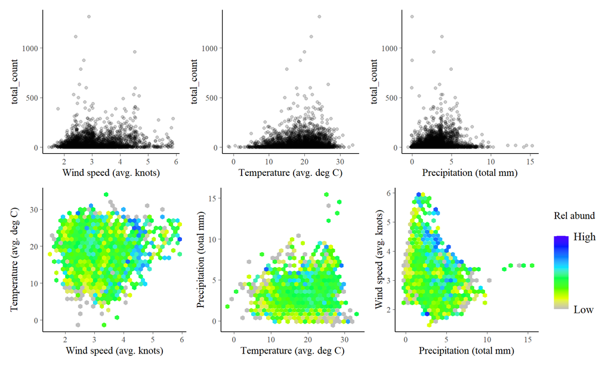

#### *Turdus migratorius* (American Robin)

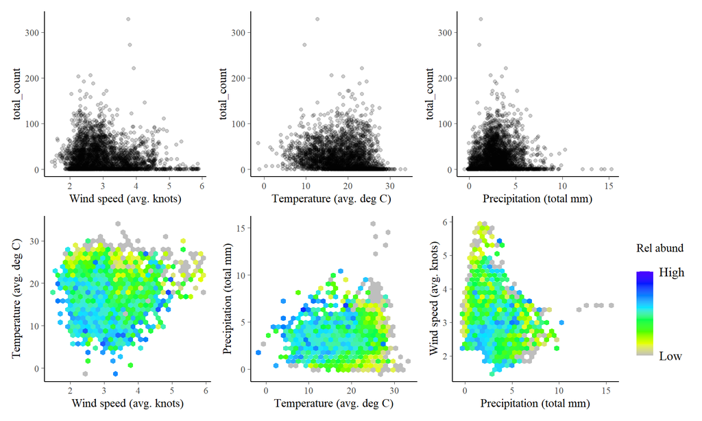

### Fish

Showing 2008-2015 data for a number of the most abundant fish species against environmental variables:

- Temperature
- Salinity
- Dissolved oxygen

**Note:** these environmental variables are recorded alongside the haul devices during trawl surveys. Only averages of the best recorded data along each haul are shown. Fish data are presented as total catch numbers divided by the area swept during that haul, denoted CPUE (catch per unit effort).

#### *Sebastolobus altivelis* (longspine thornyhead)

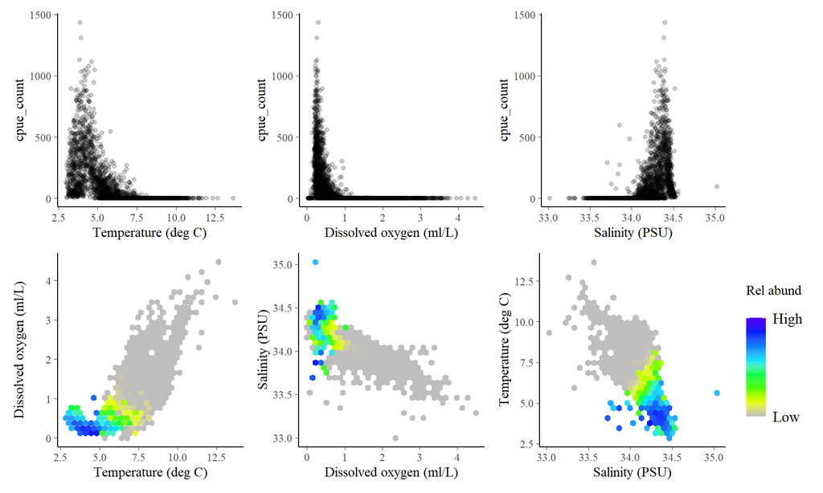

#### *Citharichthys sordidus* (Pacific sanddab)

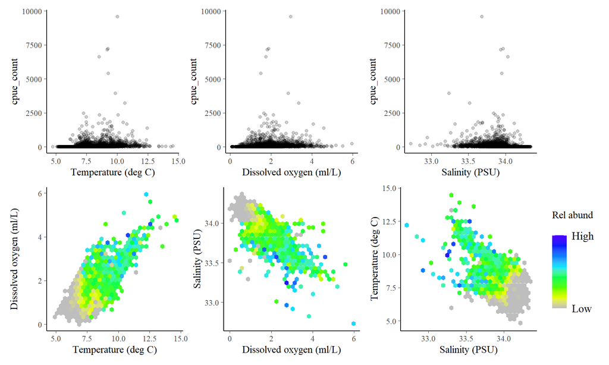